# Pre-processing ASVs with Phyloseq

Liangzi

2025-03-25

# Set Environment

## Load Packages

```r
#install.packages("BiocManager")
#BiocManager::install("Biostrings")

# NOTE, you will need to install the following 2 packages to re-create the
# negative control plots below!
#install.packages("ggpubr")
#install.packages("rstatix")

# Load packages with pacman
# Be sure that you load dada2 & Patchwork, which we didn't do in class on March 12th
pacman::p_load(devtools, phyloseq, dada2, patchwork, Biostrings, tidyverse,
               # Note to add ggpubr & rstatix!!
               ggpubr, rstatix, install = FALSE)
```

## Timing of this script

```r
# What time did we start running this script?
start_time <- Sys.time()
```

## 1. Load Data

### 1a. Metadata

```r
# load in metadata
metadata_df <-
  read_csv("data/metadata/SraRunTable.csv") %>%
  # Fix Column Name
  dplyr::rename("sample_names" = "Run") %>%
  # Add sample names also as a column
  mutate(names = sample_names)
# Inspect
head(metadata_df)
```

```
## # A tibble: 6 × 35
##   sample_names `Assay Type` AvgSpotLen    Bases BioProject  BioSample
##   <chr>        <chr>             <dbl>    <dbl> <chr>       <chr>
## 1 SRR12873300  RNA-Seq             602 38217368 PRJNA669203 SAMN16456597
## 2 SRR12873301  RNA-Seq             602 27434946 PRJNA669203 SAMN16456596
## 3 SRR12873302  RNA-Seq             602 25072698 PRJNA669203 SAMN16456595
## 4 SRR12873303  RNA-Seq             602 33445916 PRJNA669203 SAMN16456594
## 5 SRR12873304  RNA-Seq             602 31103534 PRJNA669203 SAMN16456593
## 6 SRR12873305  RNA-Seq             602 27821430 PRJNA669203 SAMN16456592
## # ℹ 29 more variables: BioSampleModel <chr>, Bytes <dbl>, `Center Name` <chr>,
## #   Collection_Date <date>, Consent <chr>, `DATASTORE filetype` <chr>,
## #   `DATASTORE provider` <chr>, `DATASTORE region` <chr>, Experiment <chr>,
## #   geo_loc_name_country <chr>, geo_loc_name_country_continent <chr>,
## #   geo_loc_name <chr>, HOST <chr>, Instrument <chr>, isolation_source <chr>,
## #   lat_lon <chr>, `Library Name` <dbl>, LibraryLayout <chr>,
## #   LibrarySelection <chr>, LibrarySource <chr>, Organism <chr>, …
```

```r
dim(metadata_df)
```

```
## [1] 29 35
```

```r
# include dada2 output
load("data/track_read_counts.RData")

# Take a look
glimpse(track_counts_df)
```

```
## Rows: 58
## Columns: 6
## $ sample_names <chr> "SRR12873300_1_filtered.fastq.gz", "SRR128733001_filtered…
## $ denoisedF    <dbl> 57736, 57736, 41697, 41697, 37077, 37077, 50268, 50268, 4…
## $ denoisedR    <dbl> 57817, 57817, 41520, 41520, 36973, 36973, 50176, 50176, 4…
## $ merged       <dbl> 54429, 54429, 41044, 41044, 34947, 34947, 49821, 49821, 4…
## $ nochim       <dbl> 38739, 38739, 37828, 37828, 29382, 29382, 47810, 47810, 4…
## $ num_ASVs     <dbl> 167, 167, 212, 212, 202, 202, 245, 245, 261, 261, 341, 34…
```

```r
dim(track_counts_df)
```

```
## [1] 58  6
```

```r
# Check filenames
head(track_counts_df$sample_names)
```

```
## [1] "SRR12873300_1_filtered.fastq.gz" "SRR128733001_filtered.fastq.gz"
## [3] "SRR12873301_1_filtered.fastq.gz" "SRR128733011_filtered.fastq.gz"
## [5] "SRR12873302_1_filtered.fastq.gz" "SRR128733021_filtered.fastq.gz"
```

```r
# Fix sample names in track_reads
track_counts_df$sample_names <- sapply(strsplit(track_counts_df$sample_names, "_"), `[`, 1)

# Intuition check
head(track_counts_df$sample_names)
```

```
## [1] "SRR12873300"  "SRR128733001" "SRR12873301"  "SRR128733011" "SRR12873302"
## [6] "SRR128733021"
```

```r
# What's different?
setdiff(track_counts_df$sample_names, metadata_df$sample_names)
```

```
##  [1] "SRR128733001" "SRR128733011" "SRR128733021" "SRR128733031" "SRR128733041"
##  [6] "SRR128733051" "SRR128733061" "SRR128733071" "SRR128733081" "SRR128733091"
## [11] "SRR128733101" "SRR128733111" "SRR128733121" "SRR128733131" "SRR128733141"
## [16] "SRR128733151" "SRR128733161" "SRR128733171" "SRR128733181" "SRR128733191"
## [21] "SRR128733201" "SRR128733211" "SRR128733221" "SRR128733231" "SRR128733241"
## [26] "SRR128733251" "SRR128733261" "SRR128733271" "SRR128733281"
```

```r
# Let's do a filtering join with left_join
metadata_final_df <-
  metadata_df %>%
  left_join(., track_counts_df, by = "sample_names") %>%
  # sample names to the rownames to merge into phyloseq
  column_to_rownames(var = "sample_names")

# Check
dim(metadata_final_df)
```

```
## [1] 29 39
```

### 1b. ASV Table

```r
asv_df1 <-
  read.delim(file = "data/ASV_table.tsv", sep = "\t",
           # add the column names and row names
           header = TRUE, row.names = 1)

# Drop the selected columns
drop_cols <- c("SRR128733001", "SRR128733011", "SRR128733021", "SRR128733031",
               "SRR128733041", "SRR128733051", "SRR128733061", "SRR128733071",
               "SRR128733081", "SRR128733091", "SRR128733101", "SRR128733111",
               "SRR128733121", "SRR128733131", "SRR128733141", "SRR128733151",
               "SRR128733161", "SRR128733171", "SRR128733181", "SRR128733191",
               "SRR128733201", "SRR128733211", "SRR128733221", "SRR128733231",
               "SRR128733241", "SRR128733251", "SRR128733261", "SRR128733271",
               "SRR128733281")

asv_df <- asv_df1 %>%
  select(-all_of(drop_cols))

# Inspect
asv_df[1:3, 1:3]
```

```
##          SRR12873300 SRR12873301 SRR12873302
## ASV_0001         298         696         502
## ASV_0002          18          12           0
## ASV_0003           0           0           0
```

```r
# fix Column names
## Remove the X: denote at the beginning "^"
colnames(asv_df) <- sub(pattern = "^X", replacement = "" , colnames(asv_df))
## Replace the . with a -: "\\." since . is a special character in regex
colnames(asv_df) <- gsub(pattern = "\\.", replacement = "-", colnames(asv_df))

# Final inspection
head(colnames(asv_df))
```

```
## [1] "SRR12873300" "SRR12873301" "SRR12873302" "SRR12873303" "SRR12873304"
## [6] "SRR12873305"
```

```r
asv_df[1:3, 1:3]
```

```
##          SRR12873300 SRR12873301 SRR12873302
## ASV_0001         298         696         502
## ASV_0002          18          12           0
## ASV_0003           0           0           0
```

### 1c. Taxonomy Table

```r
tax_df <-
  read.delim("data/ASV_taxonomy.tsv", sep = "\t",
           header = TRUE, row.names = 1)

# Inspect
dim(tax_df)
```

```
## [1] 2127    9
```

```r
dim(asv_df)
```

```
## [1] 2127   29
```

```r
# Add check
stopifnot(rownames(asv_df) == rownames(tax_df))
```

# 2. Handoff to phyloseq

```r
raw_physeq <-
  phyloseq(otu_table(asv_df, taxa_are_rows = TRUE),
         sample_data(metadata_final_df),
         tax_table(as.matrix(tax_df)))

# Check out
raw_physeq
```

```
## phyloseq-class experiment-level object
## otu_table()   OTU Table:         [ 2127 taxa and 29 samples ]
## sample_data() Sample Data:       [ 29 samples by 39 sample variables ]
## tax_table()   Taxonomy Table:    [ 2127 taxa by 9 taxonomic ranks ]
```

```r
# save
save(raw_physeq, file = "data/03_PreProcessing/raw_physeq.RData")
```

# Clean up the data!

## 3. Remove chloroplasts

```r
noChloros_physeq <-
  raw_physeq %>%
  subset_taxa(Order != "Chloroplast" | is.na(Order))

# How many ASVs were chloroplasts?
numChloros_ASVs <- ntaxa(raw_physeq) - ntaxa(noChloros_physeq)

numChloros_ASVs # There were 3 ASVs that were chloroplasts.
```

```
## [1] 3
```

## 4. Remove Mitochondria

```r
noChlorosMitos_physeq <-
  noChloros_physeq %>%
  subset_taxa(Family != "Mitochondria" | is.na(Family))

# How many ASVs were mitochondria?
numMitos_ASVs <- ntaxa(noChloros_physeq) - ntaxa(noChlorosMitos_physeq)

numMitos_ASVs # There were 9 ASVs that were mitochondria.
```

```
## [1] 9
```

**INTERPRETATION #1: How many chloroplast and/or mitochondrial ASVs in your dataset? Does this seem reasonable?** There were 3 ASVs that were chloroplasts and 9 ASVs that were mitochondria. This seem reasonable since the dataset is not plant-heavy, and maybe the primer selection minimized chloroplast and mitochondrial amplification.

# Evaluate and remove the control samples

## 5. Negative Controls

```r
# # List all sample names to check if negative control samples exist
sample_names(noChlorosMitos_physeq)
```

```
##  [1] "SRR12873300" "SRR12873301" "SRR12873302" "SRR12873303" "SRR12873304"
##  [6] "SRR12873305" "SRR12873306" "SRR12873307" "SRR12873308" "SRR12873309"
## [11] "SRR12873310" "SRR12873311" "SRR12873312" "SRR12873313" "SRR12873314"
## [16] "SRR12873315" "SRR12873316" "SRR12873317" "SRR12873318" "SRR12873319"
## [21] "SRR12873320" "SRR12873321" "SRR12873322" "SRR12873323" "SRR12873324"
## [26] "SRR12873325" "SRR12873326" "SRR12873327" "SRR12873328"
```

**INTERPRETATION #2: Did your dataset have any negative controls? If so, how many ASVs did you remove? Does that seem reasonable to you?** In this paper, the authors did not analyze the microbial community for control groups. Negative control samples don’t exist in the ‘noChlorosMitos_physeq’.

## 6. Positive Controls

**INTERPRETATION #3: Did your dataset have a mock community? If so, what can you say about the accuracy of your sequencing run?** In this paper, the authors did not analyze the microbial community for control groups.There is no mock community.

# 7. Reverse Complements

```r
# Pull out Taxa Table
tax_table <-
  noChlorosMitos_physeq %>%
  tax_table() %>%
  data.frame()

# Grab ASV Sequences and Names
asv_names <- tax_table$ASV
asv_seqs <- tax_table$ASVseqs

# Create empty comparison matrix
asv_rev_comp <- matrix(nrow=length(asv_seqs), ncol = length(asv_seqs))

# Fix the names in the rows and columns
rownames(asv_rev_comp) <- asv_names
colnames(asv_rev_comp) <- asv_names

# Convert sequences to Biostrings
asv_dna <- DNAStringSet(asv_seqs)

# Inspect
head(asv_dna)
```

```
## DNAStringSet object of length 6:
##     width seq
## [1]   387 CCGCGGTAATACGTAGGGTGCGAGCGTTAATCGG...CGCCTGGGGAGTACGGCCGCAAGGTTAAAACTT
## [2]   386 CCGCGGTAATACGGAGGGTGCAAGCGTTATCCGG...CACCTGGGGAGTACGTTCGCAAGAATGAAACTT
## [3]   387 CCGCGGTAATACGTAGGGTGCGAGCGTTAATCGG...CGCCTGGGGAGTACGGCCGCAAGGTTAAAACTT
## [4]   387 CCGCGGTAATACGTAGGGTGCGAGCGTTAATCGG...CGCCTGGGGAGTACGGCCGCAAGGTTAAAACTC
## [5]   386 CCGCGGTAATACGGAGGGTGCAAGCGTTATCCGG...CACCTGGGGAGTACGTTCGCAAGAATGAAACTC
## [6]   389 CCGCGGTAATACGGAGGGTGCAAGCGTTAATCGG...CGCCTGGGGAGTACGGCCGCAAGGTTAAAACTT
```

```r
# Construct reverse complement
asv_rev_dna <- reverseComplement(asv_dna)

# Now loop through every asv sequence to check
for(i in 1:length(asv_seqs)){ # For each asv sequence...
  match_vec <- asv_dna[i] == asv_rev_dna # Compare it to the reverse complement of every other sequence...
  asv_rev_comp[,i] <- match_vec # Write that logical vector as a new column
}

# Find how many TRUEs (matches) we have, divide by 2 because each pair occurs twice
cat("For", sum(asv_rev_comp) / 2,"ASVs, the reverse complement will need to be removed")
```

```
## For 0 ASVs, the reverse complement will need to be removed
```

**INTERPRETATION #4: Do you have any reverse complements in your dataset?** Output: For 0 ASVs, the reverse complement will need to be removed. Therefore, the dataset does not contain any reverse complement ASVs that need to be removed.

# 8. Sequencing Depth

```r
# The current data object
noChlorosMitos_physeq
```

```
## phyloseq-class experiment-level object
## otu_table()   OTU Table:         [ 2115 taxa and 29 samples ]
## sample_data() Sample Data:       [ 29 samples by 39 sample variables ]
## tax_table()   Taxonomy Table:    [ 2115 taxa by 9 taxonomic ranks ]
```

```r
# What is the library size/sequencing depth for each sample?
seqSums_df <-
  noChlorosMitos_physeq %>%
  otu_table() %>%
  # Sum each sample column
  colSums() %>%
  data.frame() %>%
  rownames_to_column(var = "names") %>%
  left_join(., metadata_final_df, by = "names")

# Rename second column
colnames(seqSums_df)[2] <- "TotalSeqs"

# check
dim(seqSums_df)
```

```
## [1] 29 40
```

```r
head(seqSums_df)
```

```
##         names TotalSeqs Assay Type AvgSpotLen    Bases  BioProject    BioSample
## 1 SRR12873300     38696    RNA-Seq        602 38217368 PRJNA669203 SAMN16456597
## 2 SRR12873301     37790    RNA-Seq        602 27434946 PRJNA669203 SAMN16456596
## 3 SRR12873302     29101    RNA-Seq        602 25072698 PRJNA669203 SAMN16456595
## 4 SRR12873303     47810    RNA-Seq        602 33445916 PRJNA669203 SAMN16456594
## 5 SRR12873304     45174    RNA-Seq        602 31103534 PRJNA669203 SAMN16456593
## 6 SRR12873305     34099    RNA-Seq        602 27821430 PRJNA669203 SAMN16456592
##                BioSampleModel    Bytes                 Center Name
## 1 Metagenome or environmental 19816770 CHINESE ACADEMY OF SCIENCES
## 2 Metagenome or environmental 14391830 CHINESE ACADEMY OF SCIENCES
## 3 Metagenome or environmental 13473539 CHINESE ACADEMY OF SCIENCES
## 4 Metagenome or environmental 18077252 CHINESE ACADEMY OF SCIENCES
## 5 Metagenome or environmental 16864536 CHINESE ACADEMY OF SCIENCES
## 6 Metagenome or environmental 14779531 CHINESE ACADEMY OF SCIENCES
##   Collection_Date Consent DATASTORE filetype DATASTORE provider
```

[output cut: 48 more lines]

```r
# Show the depth of samples
seqSums_df %>%
  dplyr::select(names, TotalSeqs) %>%
  arrange(TotalSeqs) %>%
  head()
```

```
##         names TotalSeqs
## 1 SRR12873307         0
## 2 SRR12873308         0
## 3 SRR12873309         0
## 4 SRR12873310         0
## 5 SRR12873311         0
## 6 SRR12873312         0
```

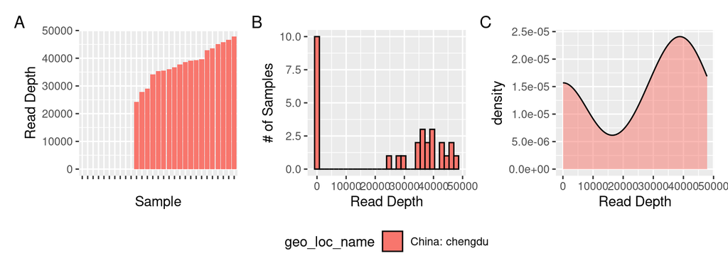

```r
# plot it as a bar plot
numSeq_bar_plot <-
  seqSums_df %>%
  ggplot(aes(x=reorder(names, TotalSeqs), y = TotalSeqs,
             fill = geo_loc_name)) +
  geom_bar(stat = "identity") +
  theme(axis.text.x = element_blank()) +
  labs(y = "Read Depth", x = "Sample") +
  theme(legend.position = "none")

# histogram
numSeq_hist_plot <-
  seqSums_df %>%
  ggplot(aes(x= TotalSeqs, fill = geo_loc_name)) +
  geom_histogram(color = "black") +
  labs(y = "# of Samples", x = "Read Depth") +
  theme(legend.position = "bottom")

# Density plot
numSeq_density_plot <-
  seqSums_df %>%
  ggplot(aes(TotalSeqs, fill = geo_loc_name)) +
  geom_density(alpha = 0.5) +
  labs(x = "Read Depth") +
  theme(legend.position = "none")

# Put it all together
numSeq_bar_plot + numSeq_hist_plot + numSeq_density_plot +
  plot_annotation(tag_levels = "A")
```

**INTERPRETATION #5: What can you conclude about your sequencing depths? What are your sample distributions? Do you have “enough” reads? Are there any samples that should be removed at this step?**

*Conclusion:* Panel A: Bar Plot of Read Depth per Sample The sequencing depth varies significantly across samples. Some samples have much lower read counts than others. If there are samples with very low sequencing depths, they may need to be removed to maintain data quality.

Panel C: Density Plot of Read Depth The distribution is bimodal, suggesting that there may be two groups of samples: 1) A group with lower read depths 2) A group with higher read depths This could indicate a mix of different sequencing qualities or batches.

*Sample Distributions:* There is a bimodal distribution, suggesting variability in sequencing depth between samples. This could be due to differences in DNA extraction, library preparation, or sequencing efficiency.

*“enough” reads?* It seems like I have enough reads.

*Any samples that should be removed?* Yes, there are some samples that should be removed. The outliers on the left side of the bar plot and histogram may be unreliable and should be excluded. In order to ensure even sequencing coverage across samples, I need to remove samples with a zero read depth.

## Remove samples with few reads

```r
# What's the min seq depth?
min(sample_sums(noChlorosMitos_physeq))
```

```
## [1] 0
```

```r
samples_to_remove <- c("SRR12873307", "SRR12873308", "SRR12873309", "SRR12873310",
                       "SRR12873311", "SRR12873312", "SRR12873313", "SRR12873314", "SRR12873317",
                       "SRR12873315")
raw_preprocessed_physeq <-
  subset_samples(noChlorosMitos_physeq, !(sample_names(noChlorosMitos_physeq) %in% samples_to_remove))

# What's the new min seq depth?
min(sample_sums(raw_preprocessed_physeq))
```

```
## [1] 24199
```

```r
# Final check of the sequencing depth for now
# Here, we could remove more samples if we needed to
seqSums_df %>%
  dplyr::select(names, TotalSeqs) %>%
  arrange(TotalSeqs) %>%
  head(n = 10)
```

```
##          names TotalSeqs
## 1  SRR12873307         0
## 2  SRR12873308         0
## 3  SRR12873309         0
## 4  SRR12873310         0
## 5  SRR12873311         0
## 6  SRR12873312         0
## 7  SRR12873313         0
## 8  SRR12873314         0
## 9  SRR12873317         0
## 10 SRR12873315         4
```

# 9. Save Output

```r
save(raw_preprocessed_physeq, file = "data/03_PreProcessing/raw_preprocessed_physeq.RData")
```

# Final info for Reproducibility

## Check Render Time

```r
# Take the time now that we are at the end of the script
end_time <- Sys.time()
end_time
```

```
## [1] "2025-03-28 20:34:40 EDT"
```

```r
# Echo the elapsed time
elapsed_time <- round((end_time - start_time), 3)
elapsed_time
```

```
## Time difference of 5.402 secs
```